# Introduction to R and the tidyverse

## Lecture 1: plotting

## Before we start: Rstudio

- Interactive console
- Object explorer
- Script window
- Plot window

## Before we start: R

- concatenate: c()
- assign: <-
- vector, matrices: rbind(), cbind()
- matrix extraction: [ ]
- variable extraction: $
- data frames: mpg

## Why do we plot

> *Why do we want to plot data?*
- we are human beings – we are pattern recognizers
- we can *see* things we are not able to grasp from data
- good to explore a dataset and look for regularities
- good to *convey a clear message*
- to have fun
- (to show your colleagues how nice your plot is)

## What do you see?

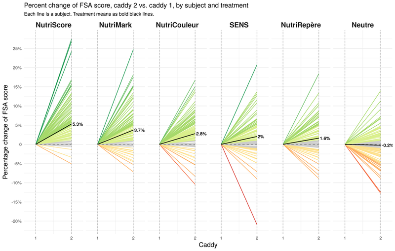

- Plots allow to convey a lot of information in a compact way

## Good plots, bad plots

- It is important to make *good* plots
- i.e., plots that *look good*…
- …and are *honest* to the data
- it is very easy to *hide* the message rather than *highlighting* it
- it is very easy to *mislead* with a plot
- so let’s start with a gallery of **bad plots**. Can you guess *why* they are bad?

## Bad plotting 1

[figure not shown]

## Bad plotting 2

[figure not shown]

## Bad plotting 3

[figure not shown]

## Bad plotting 4

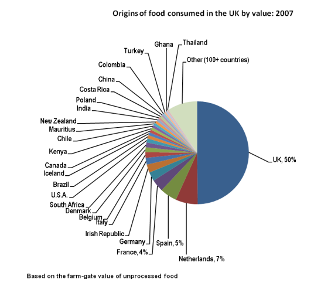

## Bad plotting 5

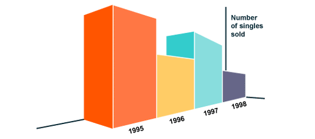

## Bad plotting 5 (really, you don’t need 3D plots)

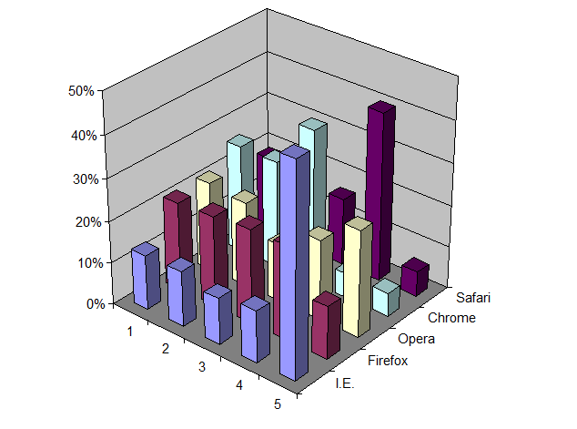

## The road to good plotting

- know your data
- think before you hit the enter button
- sketch on paper first
- be honest
- draw your axis first
- choose your visualization wisely

## Some data

We will start by using the *built-in dataset* **mpg**

```r
mpg
```

```
## # A tibble: 234 x 11
##    manufacturer model displ  year   cyl trans drv     cty   hwy fl    class
##    <chr>        <chr> <dbl> <int> <int> <chr> <chr> <int> <int> <chr> <chr>
##  1 audi         a4      1.8  1999     4 auto… f        18    29 p     comp…
##  2 audi         a4      1.8  1999     4 manu… f        21    29 p     comp…
##  3 audi         a4      2    2008     4 manu… f        20    31 p     comp…
##  4 audi         a4      2    2008     4 auto… f        21    30 p     comp…
##  5 audi         a4      2.8  1999     6 auto… f        16    26 p     comp…
##  6 audi         a4      2.8  1999     6 manu… f        18    26 p     comp…
##  7 audi         a4      3.1  2008     6 auto… f        18    27 p     comp…
##  8 audi         a4 q…   1.8  1999     4 manu… 4        18    26 p     comp…
##  9 audi         a4 q…   1.8  1999     4 auto… 4        16    25 p     comp…
## 10 audi         a4 q…   2    2008     4 manu… 4        20    28 p     comp…
## # … with 224 more rows
```

## A look at the data

- *model* : model name
- *displ* : engine displacement, in litres
- *year* : year of manufacture
- *cyl* : number of cylinders
- *trans* : type of transmission
- *drv* : f = front-wheel drive, r = rear wheel drive, 4 = 4wd
- *cty* : city miles per gallon
- *hwy* : highway miles per gallon
- *fl* : fuel type
- *class* : “type” of car

## We will be using `ggplot2`. Why?

Advantages of ggplot2

- consistent underlying `grammar of graphics` (Wilkinson, 2005)
- plot specification at a high level of abstraction
- very flexible
- theme system for polishing plot appearance
- mature and complete graphics system
- many users, active mailing list

## What is a grammar of graphics?

The basic idea: independently specify plot building blocks and combine them to create just about any kind of graphical display you want. Building blocks of a graph include:

- data
- aesthetic mapping
- geometric object
- statistical transformations
- scales
- coordinate system
- position adjustments
- faceting

## Starting from the basics

**As in a grammar the minimal sentence is a subject in a plot the minimal object is data**

```r
p <- ggplot(mpg)
```

**In a grammar, you need a verb. In plots, this is axis**

```r
p <- ggplot(mpg, aes(x = displ, y = hwy))
```

### Still no plot generated!

## Generating a plot

**But you also need an object. In ggplot, this is *geoms***

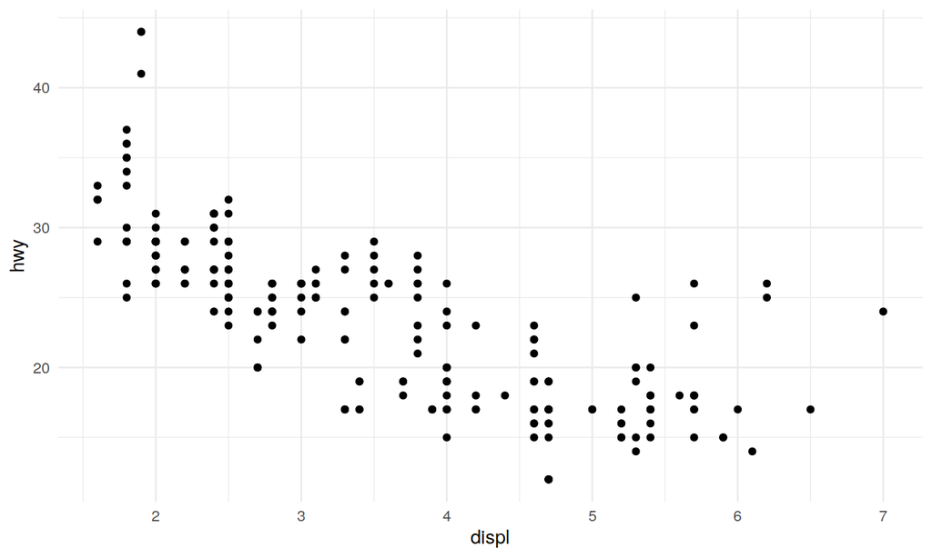

```r
p + geom_point()
```

## Generating a plot, 2

**But you also need an object. In ggplot, this is *geoms***

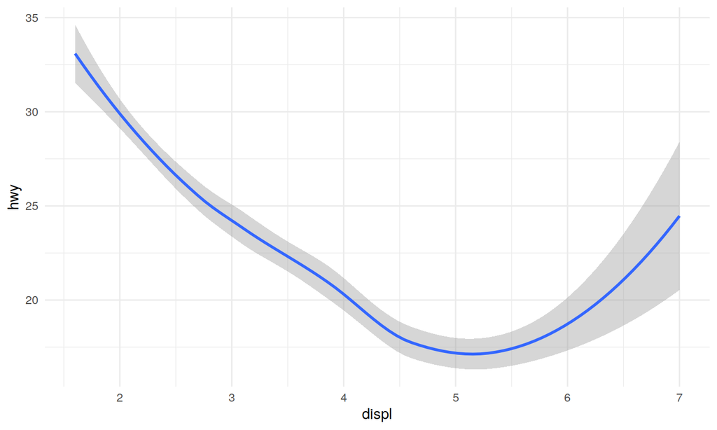

```r
p + geom_smooth()
```

## Generating a plot, 3

**But you also need an object. In ggplot, this is *geoms***

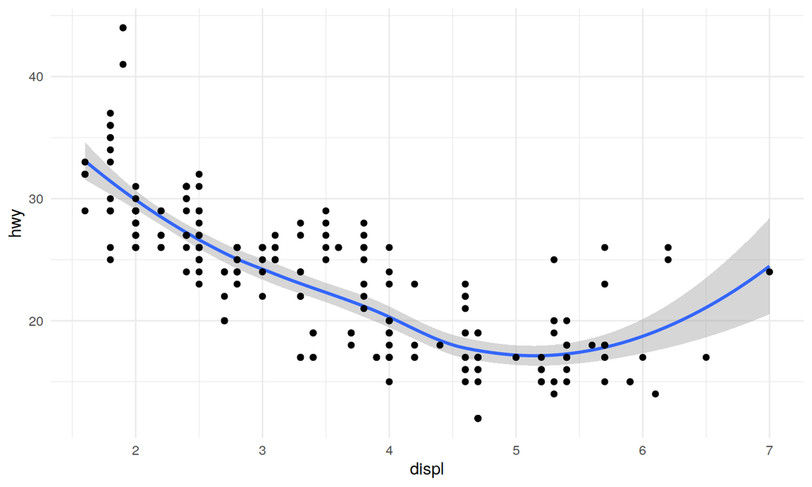

```r
p + geom_smooth()+geom_point()
```

## The beauty of a grammar metaphor

- once you get the main idea, adding things is easy
- a plot is a sentence made with data
- you add layers with `+`
- as you would add words to a sentence
- as in grammar you use adjectives to give more nuanced meaning, in plots you could use `+` to add color, fill, size, shape, etc…

## Adding meaning: color

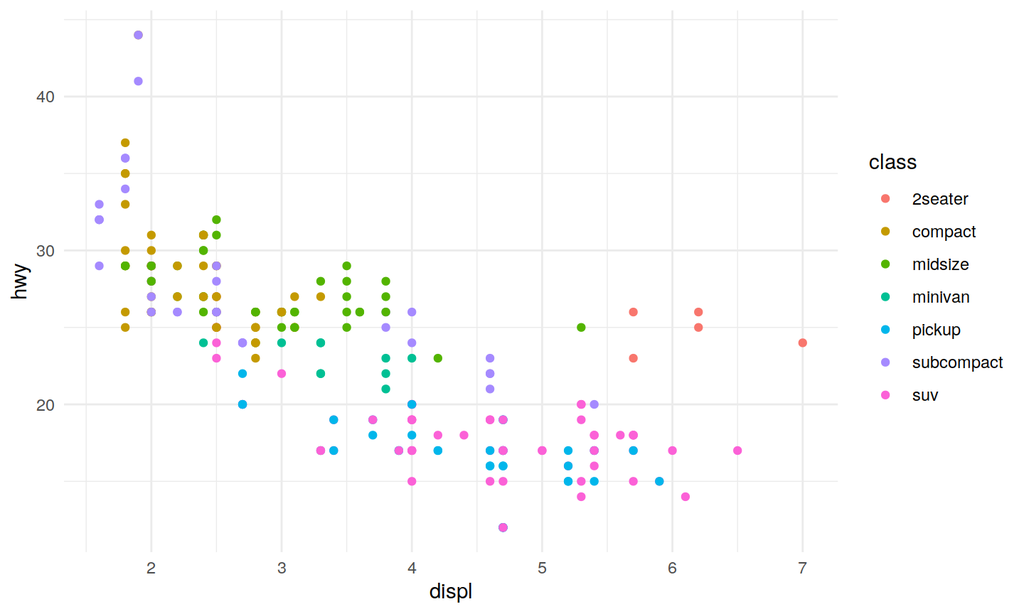

```r
p + geom_point(aes(color=class))
```

## Adding meaning: size

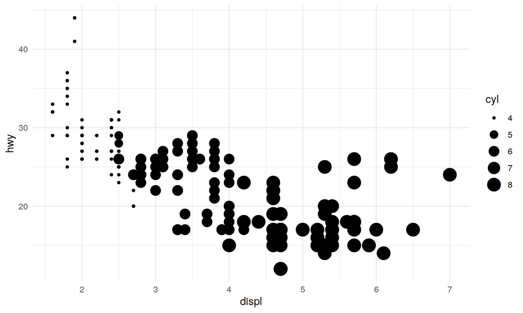

```r
p + geom_point(aes(size=cyl))
```

## Adding meaning: color AND size

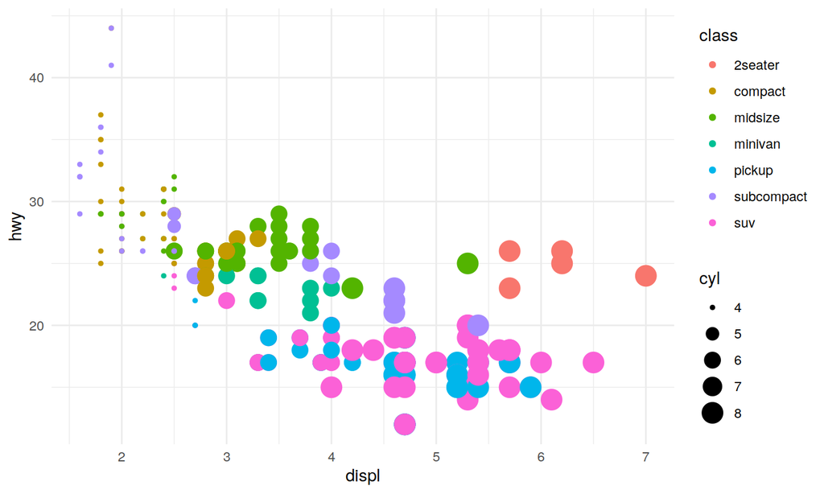

```r
p + geom_point(aes(size = cyl, color=class))
```

## Adding meaning: shape

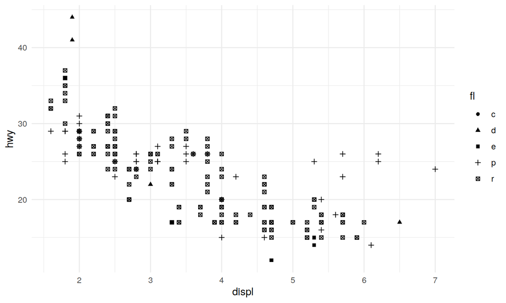

```r
p + geom_point(aes(shape=fl))
```

## Adding meaning: all together

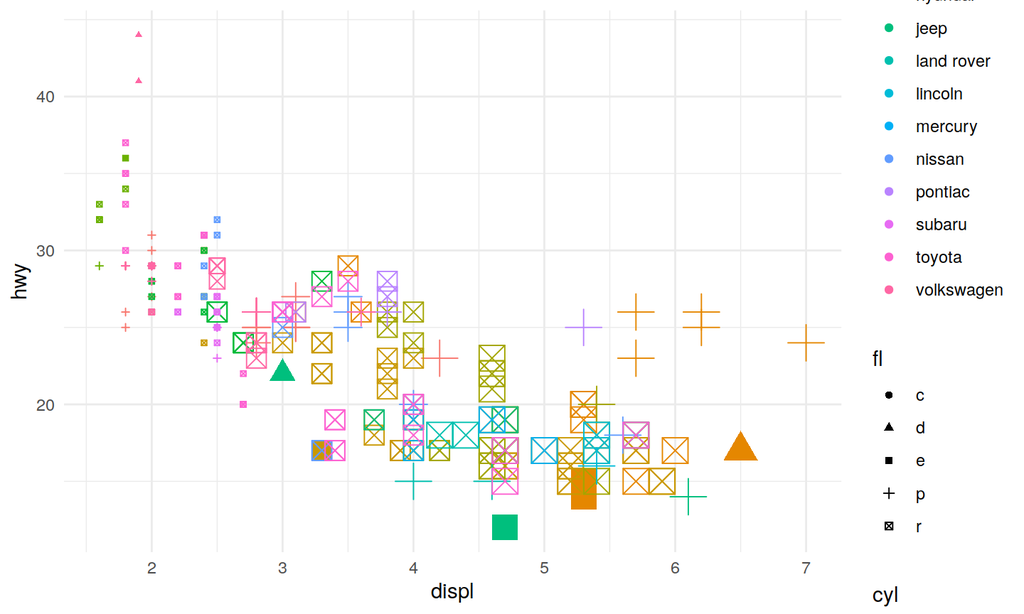

```r
p + geom_point(aes(color=manufacturer, shape =fl, size = cyl))
```

## Facets

- sometimes sentences become a bit too long
- it is useful to split them up in shorter sentences
- for instance, you could first talk about a car, *then* another one
- in plots, you can split up the plot along a variable
- so that one plot is drawn for each level of a given variable, say type of fuel

## Facets

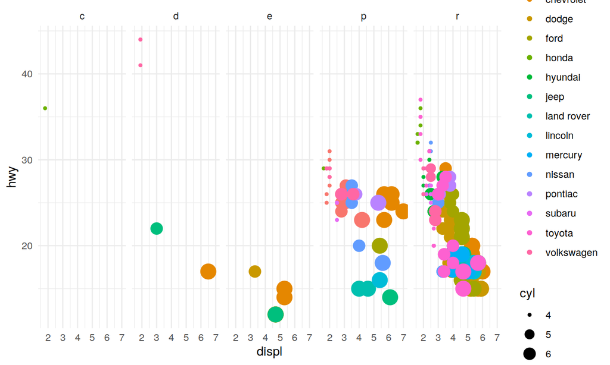

```r
p + geom_point(aes(color=manufacturer, size = cyl))+facet_grid(.~fl)
```

## More details on the grammar

A ggplot is made up of

- data (subject)
- axis (verb)
- geoms (object)
- aesthetic layers (size, fill color, shape, label, …)
- facets (splitting sentences)

And then you can change how things look and behave: - coordinate functions (changing the axis appearance and type) - scale functions (changing the appearance of the geoms) - theme functions (changing the appearance of the plot itself)

## Exploring data with plots: one variable

*Plot types depend on the variable type*

- *one-variable plots, discrete variable*: barplot
- *one-variable plots, continuous variable*: distribution, density

## Barplots

- let’s look at the drive type of the cars: front, rear, or 4wd

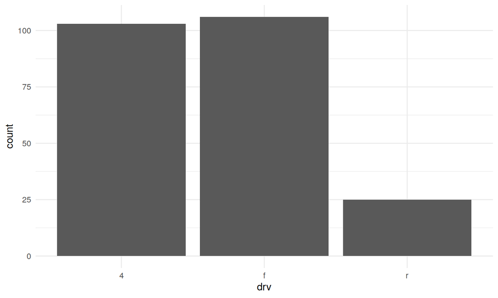

```r
p <- ggplot(mpg, aes(drv))
p + geom_bar()
```

## Barplots

- not so fancy. should we add color?

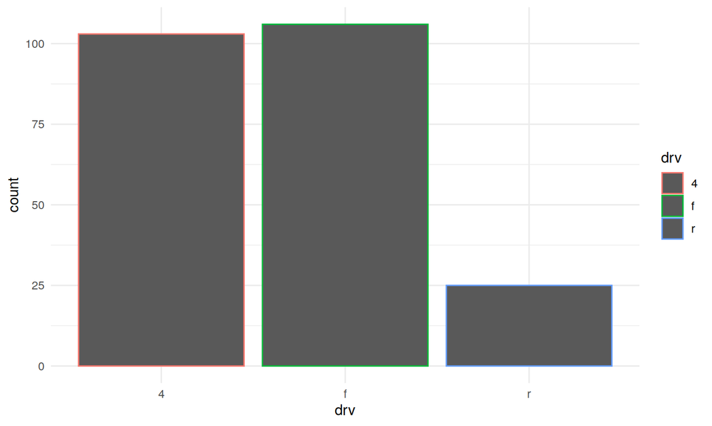

```r
p <- ggplot(mpg, aes(drv))
p + geom_bar(aes(color=drv))
```

## Barplots

- ups. Maybe we meant fill?

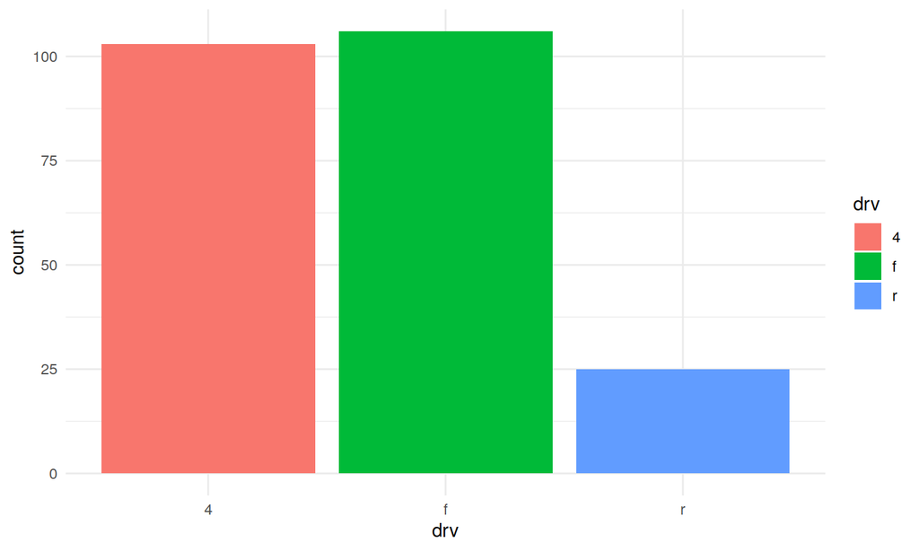

```r
p <- ggplot(mpg, aes(drv))
p + geom_bar(aes(fill=drv))
```

## Barplots

- nice. doesn’t add much information, though. what if we cross it with car class?

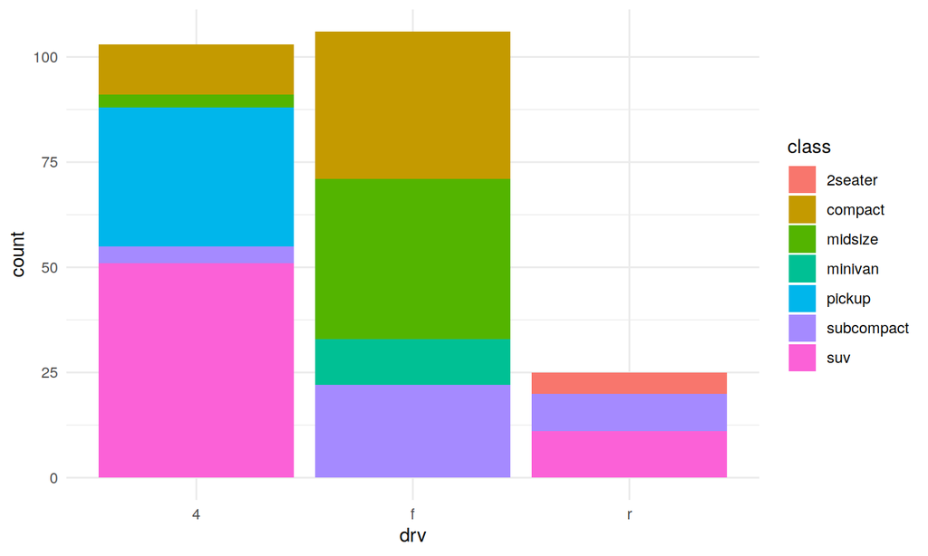

```r
p <- ggplot(mpg, aes(drv))
p + geom_bar(aes(fill=class))
```

## Barplots

- By default stacked. How to unstack?

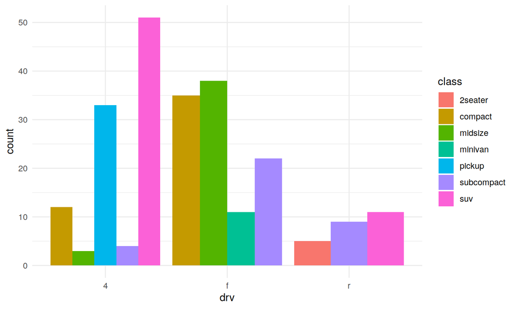

```r
p <- ggplot(mpg, aes(drv))
p + geom_bar(aes(fill=class), position = position_dodge())
```

## Barplots

- By default stacked. How to show relative weight?

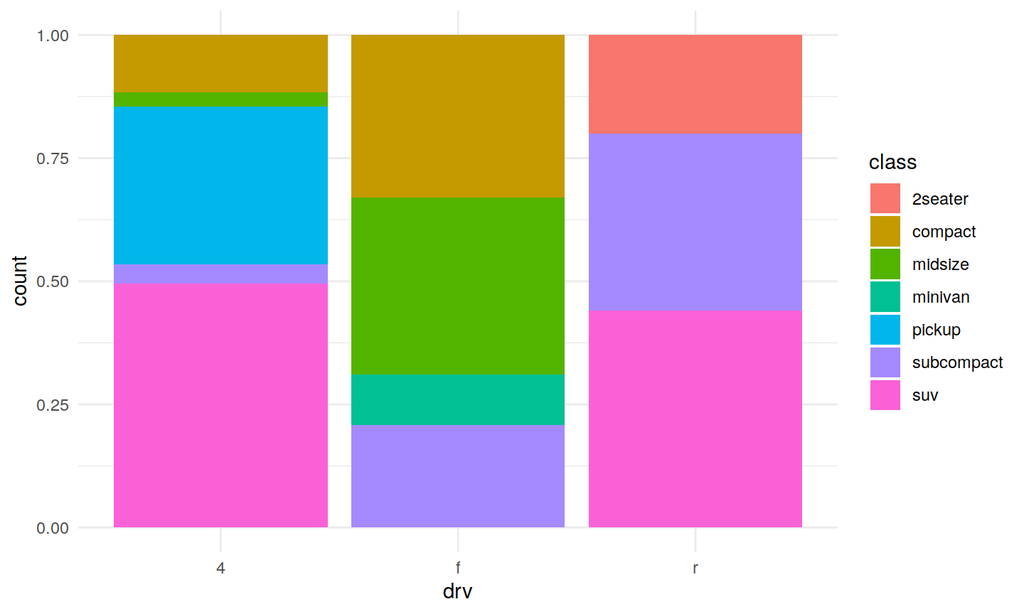

```r
p <- ggplot(mpg, aes(drv))
p + geom_bar(aes(fill=class), position = position_fill())
```

## One variable, continuous: mpg on highway

- When the variable is continuous, it makes more sense to show distributions

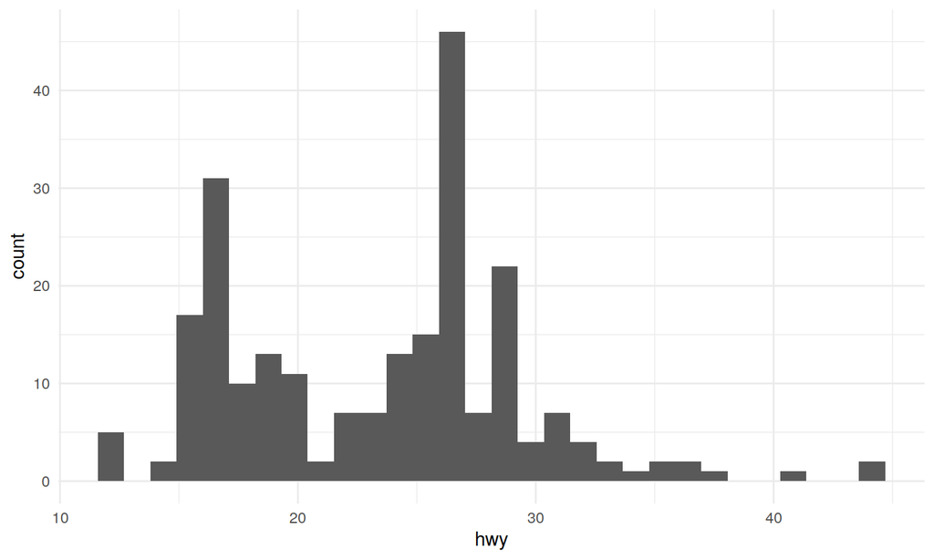

```r
p <- ggplot(mpg, aes(hwy))
p + geom_histogram()
```

## Histograms: binwidth

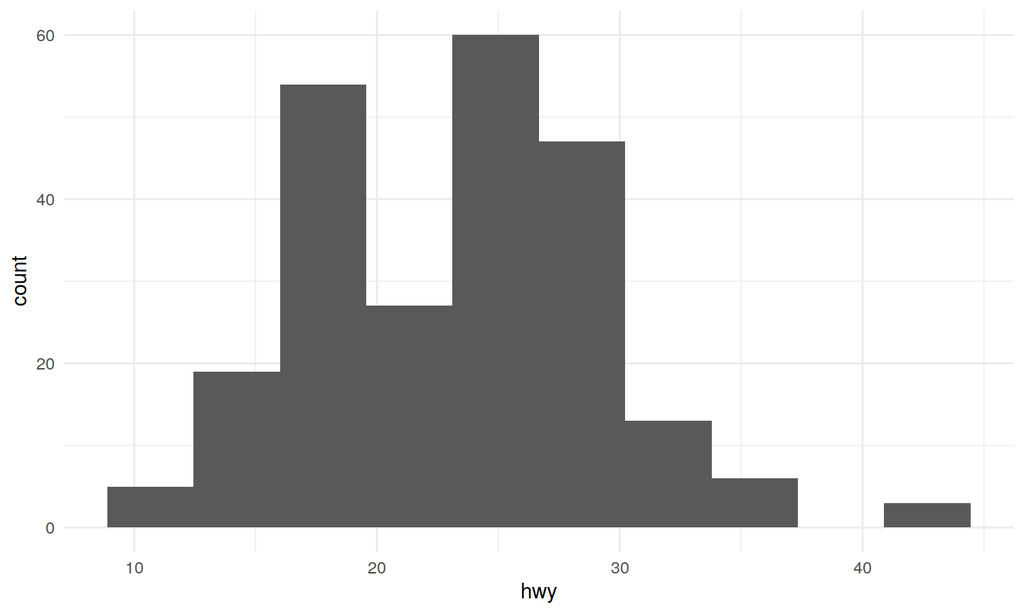

```r
p + geom_histogram(bins = 10)
```

## Histograms: binwidth

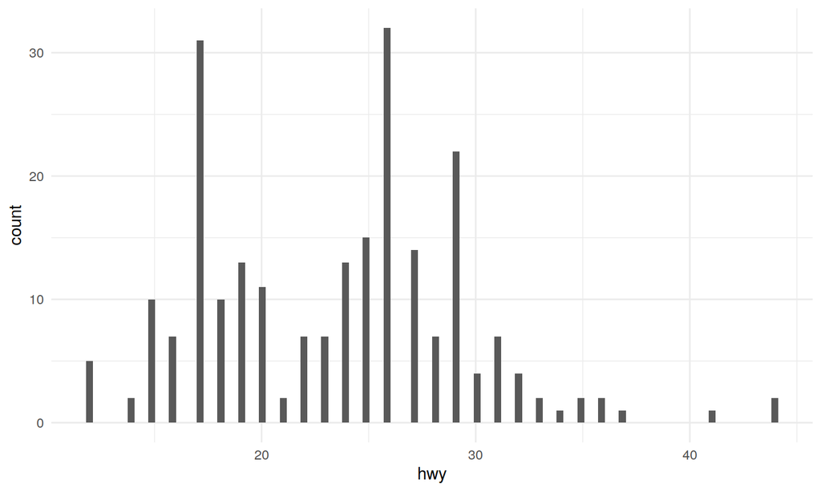

```r
p + geom_histogram(bins = 100)
```

## An alternative do histogram: dotplot

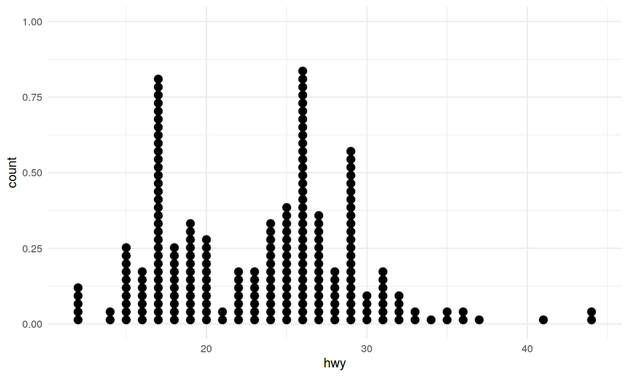

```r
p + geom_dotplot(binwidth = 0.5)
```

## Continuous distribution: Kernel Density Estimation

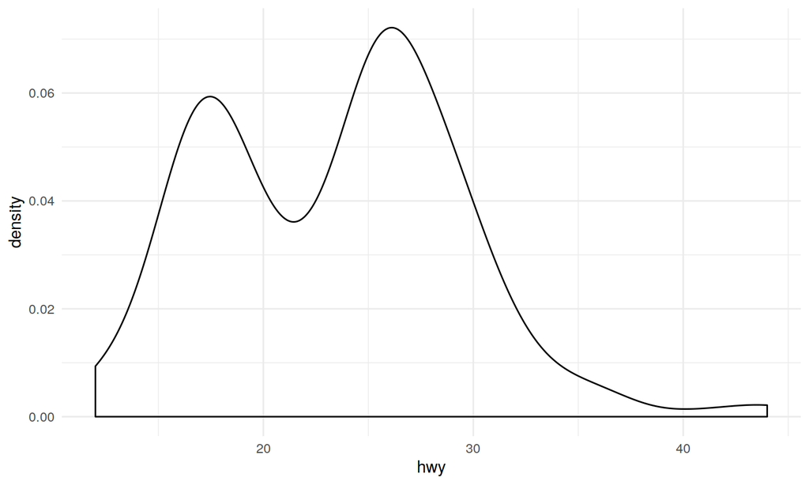

```r
p + geom_density()
```

## Continuous distribution: Kernel Density Estimation

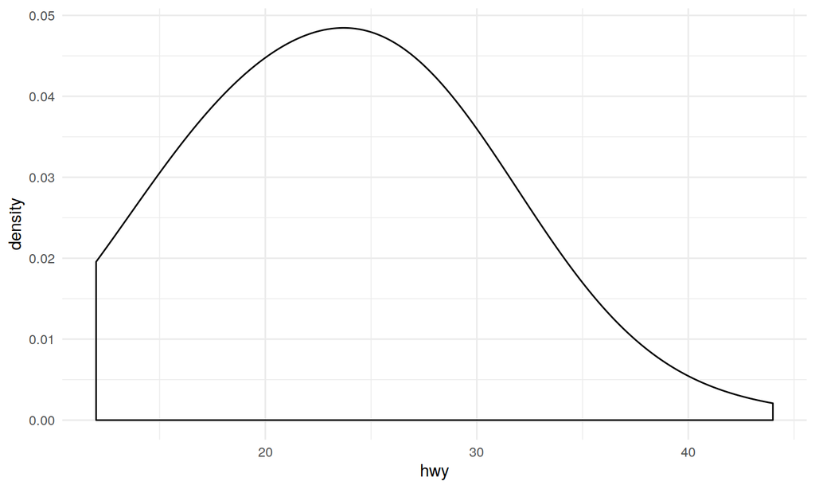

```r
p + geom_density(adjust = 3)
```

## Continuous distribution: Kernel Density Estimation

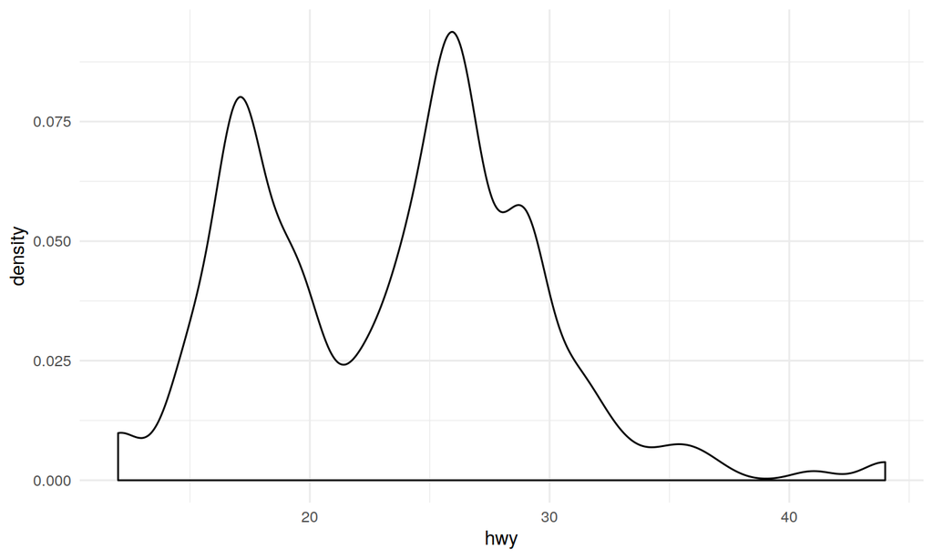

```r
p + geom_density(adjust = 0.5)
```

## Additional resources

- try to look for PlotCon2016 videos, and especially [this one](https://www.youtube.com/watch?v=RG_BKQRbJZw)
- …